# Лабораторная работа №2. Вариант 1.

Работу выполнил студент группы 382006-1 Пикин Илья.

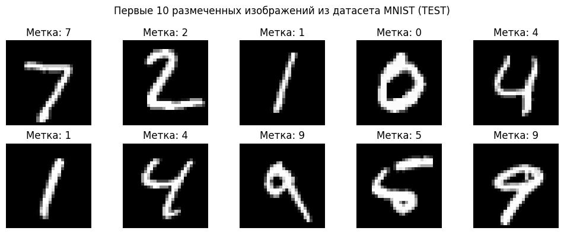

```python
from torchvision import datasets, transforms
import matplotlib.pyplot as plt
from sklearn.cluster import KMeans, DBSCAN, AgglomerativeClustering
from sklearn.metrics import adjusted_rand_score

# Установка датасета MNIST
transform = transforms.Compose([transforms.ToTensor(), transforms.Normalize((0.5,), (0.5,))])
mnist_test = datasets.MNIST(root='./data', train=False, transform=transform, download=True)


# Извлечение первых 10 изображений из MNIST
images = mnist_test.data[:10]
labels = mnist_test.targets[:10]

# Вывод изображений с помощью matplotlib
fig, axs = plt.subplots(2, 5, figsize=(10, 4))
fig.suptitle('Первые 10 размеченных изображений из датасета MNIST (TEST)')
for i, ax in enumerate(axs.flatten()):
    ax.imshow(images[i], cmap='gray')
    ax.set_title(f'Метка: {labels[i]}')
    ax.axis('off')
plt.tight_layout()
plt.show()
```

```python
# Извлечение данных и меток
mnist_test_data = mnist_test.data
mnist_test_labels = mnist_test.targets

# Изменение формата данных
mnist_test_data = mnist_test_data.reshape(-1, 28 * 28)
mnist_test_data = mnist_test_data.float() / 255.0
```

# Кластеризация с использованием алгоритма k-means

```python
# Кластеризация с использованием алгоритма k-means
kmeans = KMeans(n_clusters=10, init='k-means++', n_init=10)
kmeans.fit(mnist_test_data)
kmeans_labels = kmeans.predict(mnist_test_data)
ari_kmeans = adjusted_rand_score(mnist_test_labels, kmeans_labels)
print(f"Adjusted Rand Index (ARI) для  k-means: {ari_kmeans}")
```

```
Adjusted Rand Index (ARI) для  k-means: 0.3804028888549522
```

# Кластеризация с использованием алгоритма DBSCAN

```python
# Кластеризация с использованием алгоритма DBSCAN
dbscan = DBSCAN(eps=5.5, min_samples=15)
dbscan_labels = dbscan.fit_predict(mnist_test_data)
ari_dbscan = adjusted_rand_score(mnist_test_labels, dbscan_labels)
print(f"Adjusted Rand Index (ARI) для DBSCAN: {ari_dbscan}")
```

```
Adjusted Rand Index (ARI) для DBSCAN: 0.10964585198584507
```

# Кластеризация с использованием алгоритма Agglomerative Clustering

```python
# Кластеризация с использованием алгоритма Agglomerative Clustering
agg_clust_labels = AgglomerativeClustering(n_clusters=10).fit_predict(mnist_test_data)
ari_agg_clust = adjusted_rand_score(mnist_test_labels, agg_clust_labels)
print(f"Adjusted Rand Index (ARI) для Agglomerative Clustering: {ari_agg_clust}")
```

```
Adjusted Rand Index (ARI) для Agglomerative Clustering: 0.6063391081376247
```

# Выводы

Наименьшую точность кластеризации на датасете MNIST показал алгоритм DBSCAN. Это можно объяснить тем, что данные имеют высокую размерность, облака точек пересекаются, сильно разрежены и не имеют четко выраженных границ. Трудно подобрать параметры эпсилон и n, плохо работатет достижимость по плотности на этих данных.

Лучше всех с кластеризацией MNIST справился алгоритм иерархического кластерного анализа (Agglomerative Clustering с методом Уорда). В Agglomerative Clustering новые кластеры создаются путем объединения более мелких кластеров и, таким образом, дерево создается от листьев к стволу. В отличие от других методов кластерного анализа, для оценки расстояний между кластерами здесь используются методы дисперсионного анализа. В качестве расстояния между кластерами берётся прирост суммы квадратов расстояний объектов до центра кластера, получаемого в результате их объединения. На каждом шаге алгоритма объединяются такие два кластера, которые приводят к минимальному увеличению дисперсии. Этот метод применяется для задач с близко расположенными кластерами, как в нашем случае.